# BaiTap3_Cau2_2_1

Mu Ham Mach A Mine

2025-03-18

**Bài tập 2.2.1: Áp dụng phương pháp tích phân Monte Carlo tính các tích phân sau:**

**Câu 1**

**Bước 1: Xác định miền tích phân**

Biến x chạy từ 0 đến 1. Giá trị của tích phân có thể được xấp xỉ bằng phương pháp Monte Carlo như sau

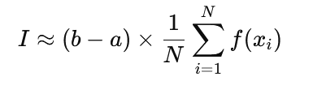

Với:

N là số lượng điểm lấy mẫu ngẫu nhiên.

xi là các giá trị ngẫu nhiên trong khoảng [0,1]

a=0, b=1, nên b−a=1

**Bước 2: Tính toán**

```r
# Số lượng điểm lấy mẫu
N <- 1000000  # 10^6 điểm

# Sinh N điểm ngẫu nhiên x trong khoảng [0,1]
x_samples <- runif(N, min=0, max=1)

# Tính f(x) = x^2 tại từng điểm
f_values <- x_samples^2

# Xấp xỉ tích phân bằng giá trị trung bình nhân với độ dài đoạn [0,1]
integral_estimate <- mean(f_values) * (1 - 0)

# In kết quả
cat("Giá trị xấp xỉ của tích phân:", integral_estimate, "\n")
```

```
## Giá trị xấp xỉ của tích phân: 0.3332735
```

**Câu 2**

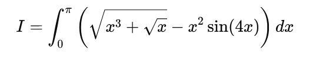

**Bước 1: Xác định miền tích phân**

Biến x chạy từ 0 đến π. Giá trị của tích phân có thể được xấp xỉ bằng phương pháp Monte Carlo như sau

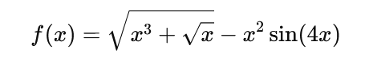

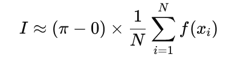

Với:

N là số lượng điểm lấy mẫu ngẫu nhiên.

xi là các giá trị ngẫu nhiên trong khoảng [0,π]

**Bước 2: Tính toán**

```r
# Số lượng điểm lấy mẫu
N <- 1000000  # 10^6 điểm

# Sinh N điểm ngẫu nhiên x trong khoảng [0, pi]
x_samples <- runif(N, min=0, max=pi)

# Tính f(x) = sqrt(x^3 + sqrt(x)) - x^2 * sin(4*x) tại từng điểm
f_values <- sqrt(x_samples^3 + sqrt(x_samples)) - x_samples^2 * sin(4*x_samples)

# Xấp xỉ tích phân bằng giá trị trung bình nhân với độ dài đoạn [0, pi]
integral_estimate <- mean(f_values) * pi

# In kết quả
cat("Giá trị xấp xỉ của tích phân:", integral_estimate, "\n")
```

```
## Giá trị xấp xỉ của tích phân: 10.51715
```

**Câu 3**

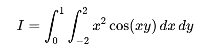

**Bước 1: Xác định miền tích phân**

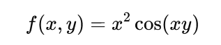

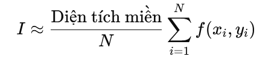

Trong đó, diện tích miền là (1−0)×(2−(−2))=4

**Bước 2: Tính toán**

```r
# Số lượng điểm lấy mẫu
N <- 1000000  # 10^6 điểm

# Sinh ngẫu nhiên N điểm (x, y) trong miền [0,1] x [-2,2]
x_samples <- runif(N, min=0, max=1)
y_samples <- runif(N, min=-2, max=2)

# Tính giá trị của hàm tại các điểm lấy mẫu
f_values <- x_samples^2 * cos(x_samples * y_samples)

# Xấp xỉ tích phân bằng giá trị trung bình nhân với diện tích miền
area <- (1 - 0) * (2 - (-2))  # Diện tích của miền tích phân
integral_estimate <- mean(f_values) * area

# In kết quả
cat("Giá trị xấp xỉ của tích phân:", integral_estimate, "\n")
```

```
## Giá trị xấp xỉ của tích phân: 0.8712921
```

**Câu 4**

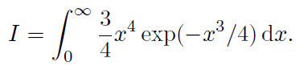

**Bước 1: Xác định miền tích phân**

Chúng ta cần xác định hàm g(x) và hàm mật độ f(x) sao cho tích phân có thể được viết dưới dạng:

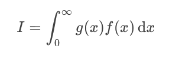

Khi đó, ta chọn:

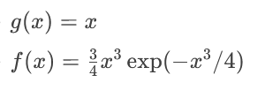

**Bước 2: Tính toán**

```r
# Số lượng mẫu
n <- 1000000

# Hàm mật độ f(x)
f <- function(x) {
  (3/4) * x^3 * exp(-x^3 / 4)
}

# Hàm g(x)
g <- function(x) {
  x
}

# Hàm để phát sinh mẫu từ phân phối có hàm mật độ f(x)
# Sử dụng phương pháp biến đổi ngẫu nhiên hoặc phương pháp lấy mẫu quan trọng
# Ở đây, chúng ta sử dụng phương pháp lấy mẫu quan trọng với phân phối mũ

# Hàm để phát sinh mẫu từ phân phối mũ
generate_samples <- function(n) {
  # Chọn một phân phối mũ với tham số lambda
  lambda <- 1
  rexp(n, rate = lambda)
}

# Phát sinh mẫu
samples <- generate_samples(n)

# Tính trọng số quan trọng
weights <- f(samples) / dexp(samples, rate = 1)

# Tính ước lượng Monte Carlo
I_hat <- mean(g(samples) * weights)

# In kết quả
cat("Ước lượng tích phân I là:", I_hat, "\n")
```

```
## Ước lượng tích phân I là: 2.272501
```